# warmup01-Mallika-Kolar

Mallika Kolar

1/29/2019

# **Star Wars**

I chose the character *Tamara Ryvora*

One of her quotes is:

> It’s good to go.

| Characteristic | Description |
| --- | --- |
| Species | Human |
| Gender | Female |
| Eye Color | Brown |
| Hair Color | Black |
| Skin Color | Dark |

[figure not shown]

# **Recipe**

I chose the recipe for *Shakshuka*

**Ingredients**  
- 1/4 cup olive oil  
- 5 Anaheim chiles  
- 1 small yellow onion  
- 5 cloves garlic  
- 1 teaspoon ground cumin  
- 1 tablespoon paprika  
- 1 can of whole peeled tomatoes  
- 6 eggs  
- 1/2 cup feta cheese  
- 1 tablespoon chopped flat-leaf parsley

**Special Kitchen Tools**  
- skillet

**Steps**  
1. Heat oil, and then add chiles and onions until golden brown  
2. Add garlic, cumin, and paprika  
3. Add crushed tomotoes and some water, while you stir occasionally  
4. Add salt as needed  
5. Add eggs of the surface, so they are evenly distributed

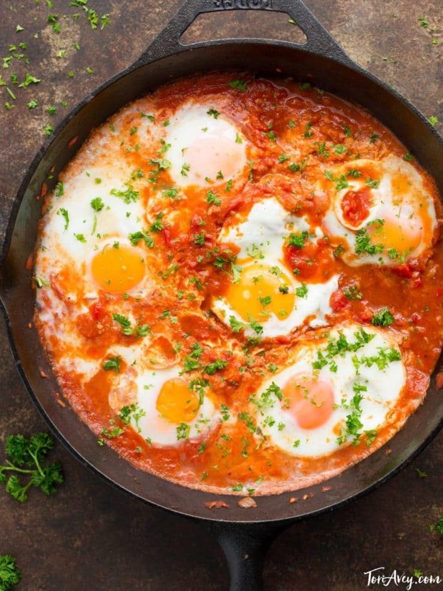

There is no specific reason to make Shakshuka.

Possible other ingredients include:  
- Feta cheese for extra taste  
- Bread or pita

# **Euclidean Distance**

## **Definition**

The **Euclidean distance** between points **p** and **q** is the length of the line segment connecting them (**pq**)  
In Cartesian Coordinates, if **p** = $(p_1, p_2,...,p_n)$ and **q** = $(q_1, q_2,...,q_n)$ are two points in Euclidian n-space, then the distance (d) from **p** to **q**, or from **q** to **p** is gien by the Pythagorean formula:  
$d$(**p**,**q**) = $d$(**q**,**p**) = $\sqrt[]{(q_1-p_1)^2 + (q_2-p_2)^2 +...+ (q_n-p_n)^2}$  
= $\sqrt[]{\displaystyle\sum_{i=1}^{n} (q_i-p_i)^2}$.  
The position in a Euclidean *n*-space is a Euclidean vector. So **p** and **q** may be represented as Euclidean vectors, starting from the origin of the space (initial point) with their tips (terminal points) ending at the two points. The Euclidean norm, or **Euclidean length**, or **magnitude** of a vector measures the length of the vector:  
$||{\textbf{p}}|| = \sqrt[]{p_1^2 + p_2^2 +...+ p_n^2} = \sqrt[]{\textbf{p} \cdot \textbf{p}}$,  
where the last expression involves the dot product.